# Reliever Report: Antonio Menendez

Wake Forest University | Sophmore | Right | 6’4" | 225

Data from Games Prior to March 18, 2019

## Pitch Location Densities

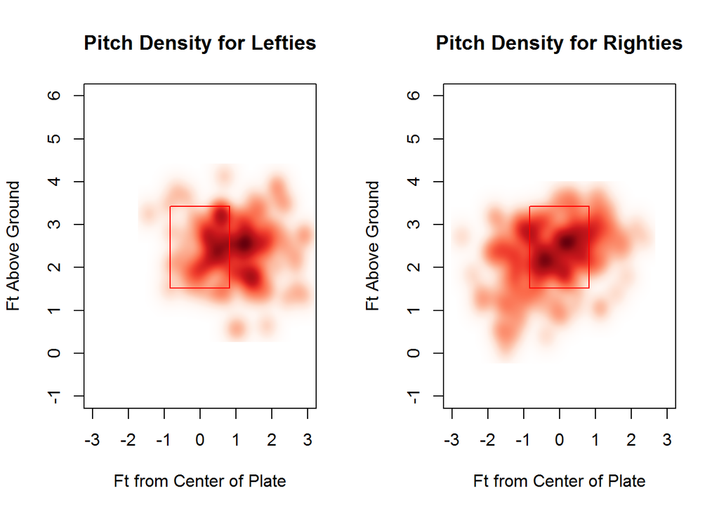

Pitch density for leftie batters shows high density on the outer half of the plate and within a ball and half’s distance off of the plate. Height densities within these ranges show favoring of belt height, the upper outside corner, and knee height off the plate.

Pitch density for rightie batters shows a much fuller spread than for leftie batters, with the inside and outside of the plate being equally favored. There are dense hotspots down the middle, on the lower half of the outside corner, and high outside and inside.

## Strikes v. Balls

### Location Densities

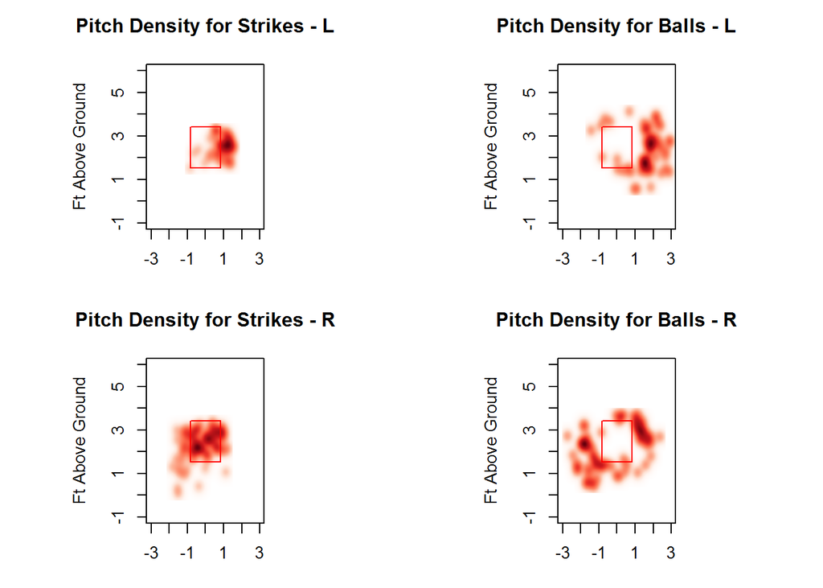

Pitch density for leftie batters shows that most strikes on lefties are a ball off of the outside of the plate and belt height. Pitches thrown more than a ball’s distance off of the plate are likely to be called a ball. Pitches on the lower half of the plate are strikes less consistently despite being located within the general strike zone (could be anomolies due to batter heights).

Pitch density for righties shows more strikes occurring dramatically outside of the strike zone than for lefties, mostly outside and below the knee, but more pitches overall are being thrown dramatically outside. Like with lefties, pitch density shows that strikes are occurring within a ball’s distance off of the plate. Inside strikes, however, are within half of a ball off of the inside of the plate. Inside pitches past this distance are routinely being called balls. Pitches most often resulting in strikes are low outside, down the middle, and at the hands inside.

### Pitch Type Locations

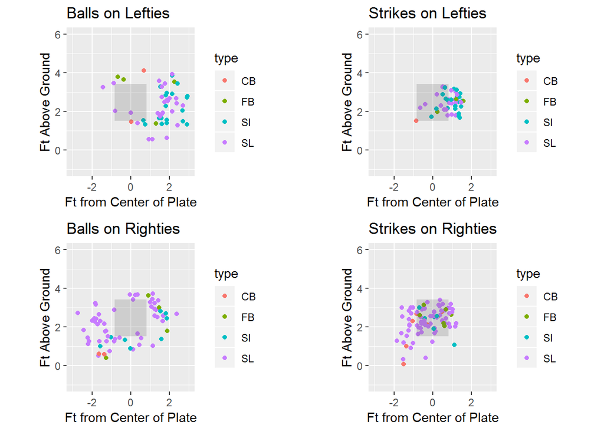

Pitch type scatterplot for leftie batters shows a relative equality in number of strikes that are sliders and sinkers. Overall this is not disproportionate from the number of overall pitches of each type thrown to lefties, so this graph does not provide much insight.

Pitch type scatterplot for righties is also not particularly revealing.

## Hits v. BHIP Outs

### Location Densities

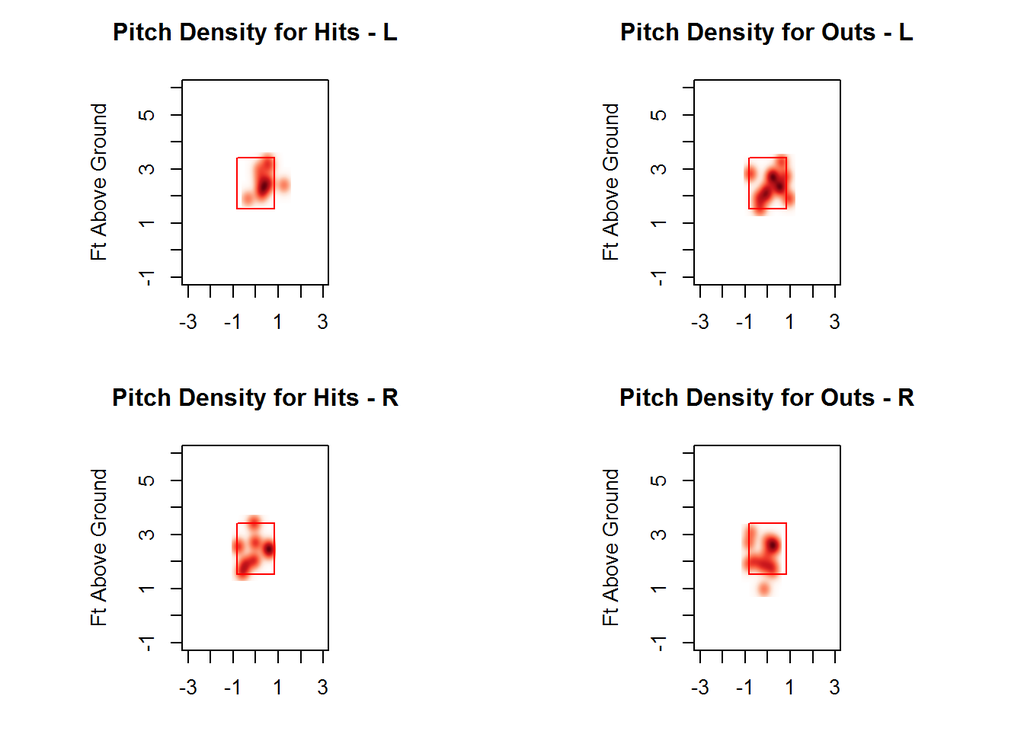

Pitch density for lefties shows a clear hotspot for hits at belt height and a ball off of the middle of the plate. Hotspots for outs are belt height two balls off of the middle of the plate, one ball outside and up from the center of the plate, and pitches thrown on the lower inside of the plate.

Pitch density for righties shows hits are occurring most often on the very edge of the outside corner of the plate and belt high inside. Outs are mostly a ball up and inside from the center of the plate or in the quarter circle surrounding the lower outside corner of the plate.

### Pitch Type Locations

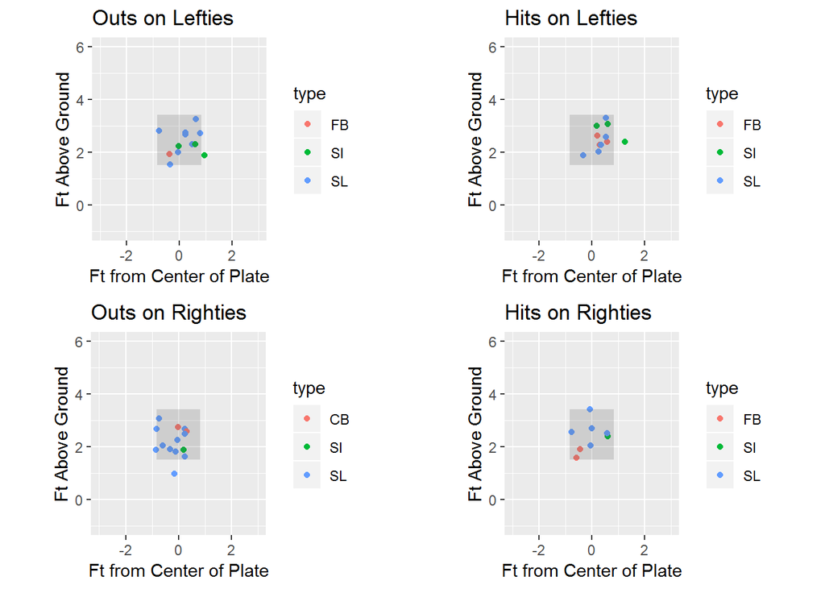

Pitch type scatterplot for lefties shows that sinkers are resulting in outs rather than hits on the bottom half of the plate. High sliders (upper half of the plate) on lefties are more likely to result in outs.

Pitch type scatterplot for righties shows that sliders are likely to be outs if located right on the outside or bottom edges of the plate. Curveballs have resulted in outs even when being thrown down the middle.

## Strikeout Pitches

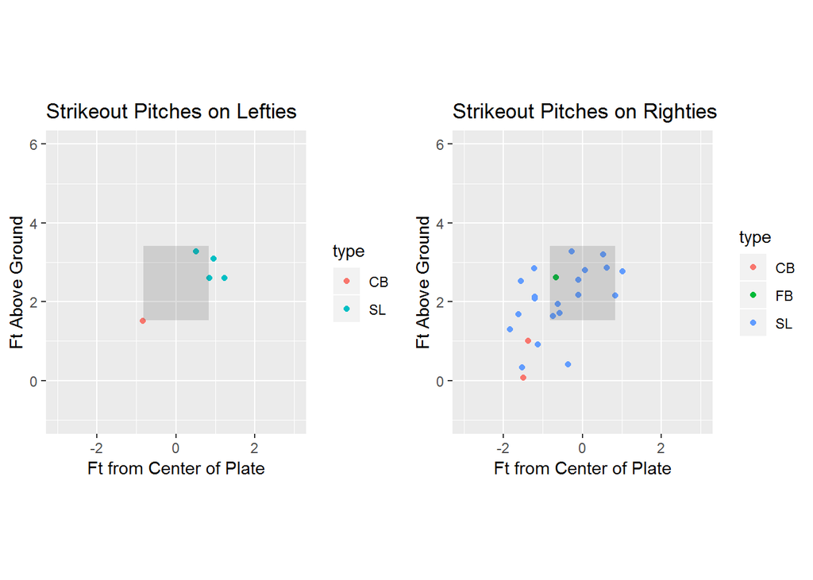

The most common strikeout pitch for lefties is a slider high and outside.

Sliders are the most common strikeout pitch for righties with no distinct clustering, but it is noteable that many of these are off the plate outside and/or low.

## Sliders

### Location Densities

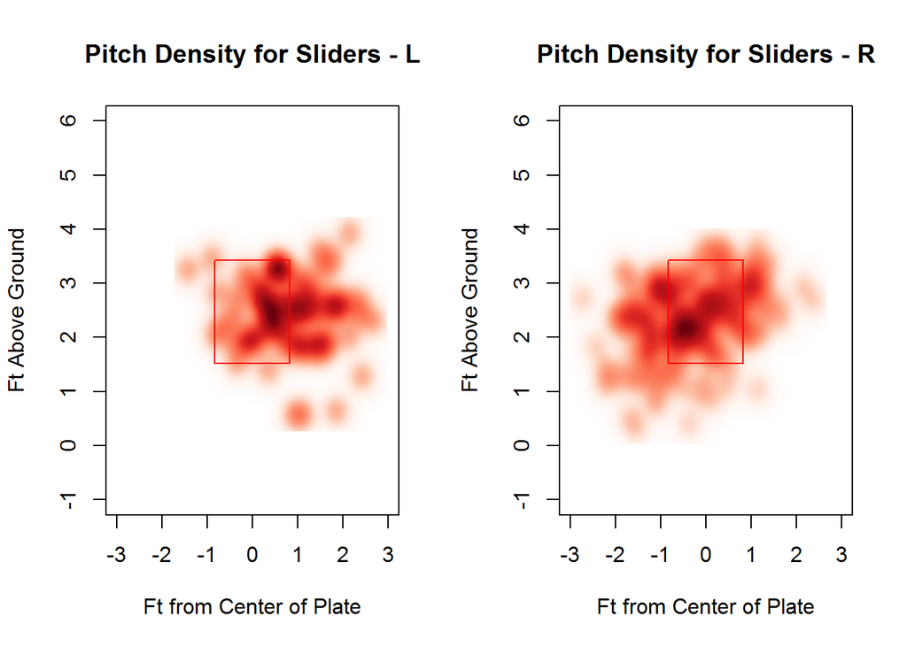

Pitch density for lefties shows that sliders to lefties are being thrown mostly outside, mostly belt height on the outer two feet of the plate, with another hotspot on the high outside corner.

Pitch density for righties shows that sliders to righties are being thrown more evenly, with the biggest hotspot being low and outside.

### Velocity Distributions

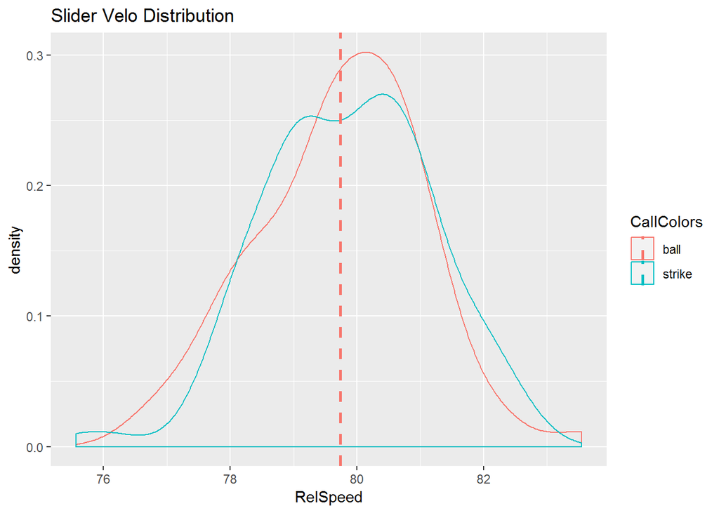

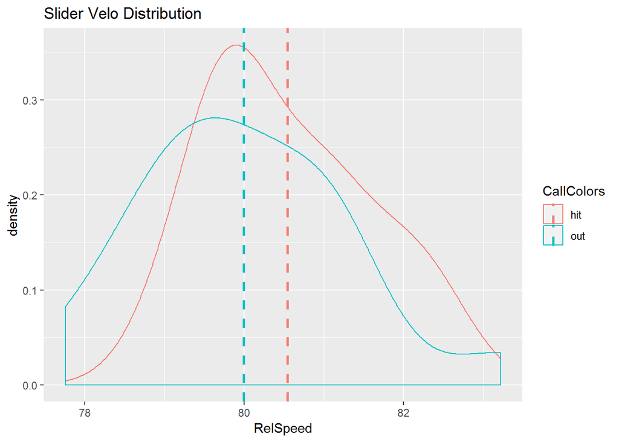

Sliders that are being hit average 80.5 mph while sliders that result in outs average 80 mph. The distributions look similar so there may not be a true difference with a larger sample size, but it does appear that sliders thrown below 79.5 mph are more likely to result in outs.

Based on visual analysis, the increased proportion of outs on balls in play is not due to the ball being placed out of the strike zone.

### Release Height Distributions

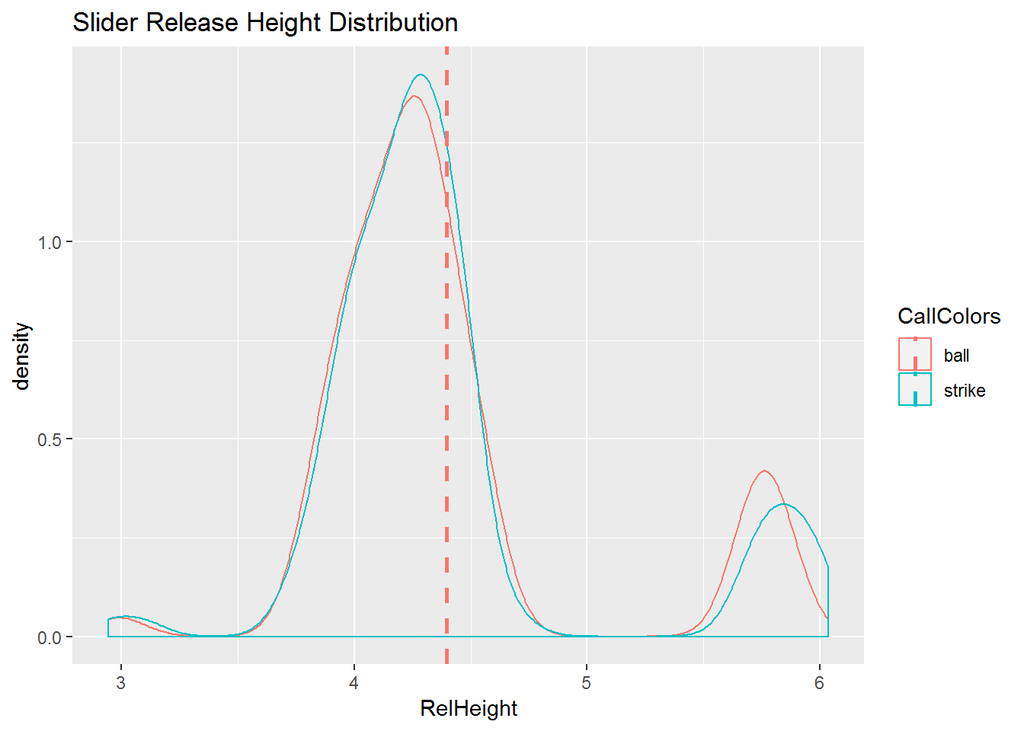

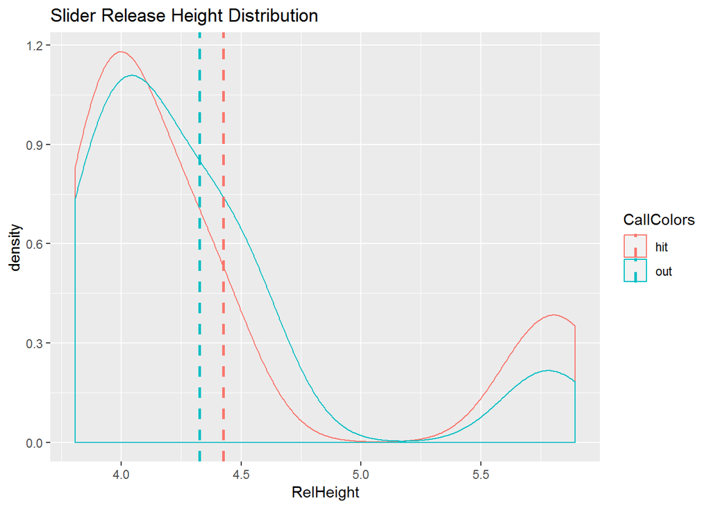

Release height distributions show that sliders are thrown at release heights of 3, 4.25, and 5.75. The distributions for balls and strikes are the same, but sliders thrown from the top slot seem more likely to be strikes when thrown from a slightly higher release point. Hits and outs have the same distribution, with hits appearing to occur slightly more when the pitch is released from 5.75 .

### Spin Axis Distributions

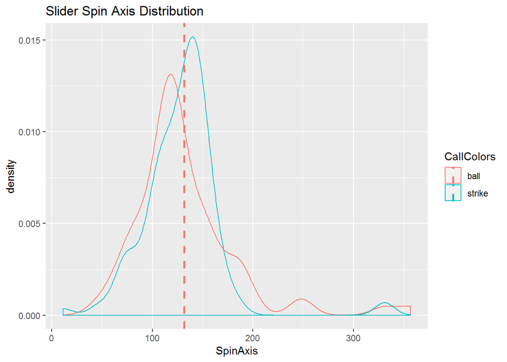

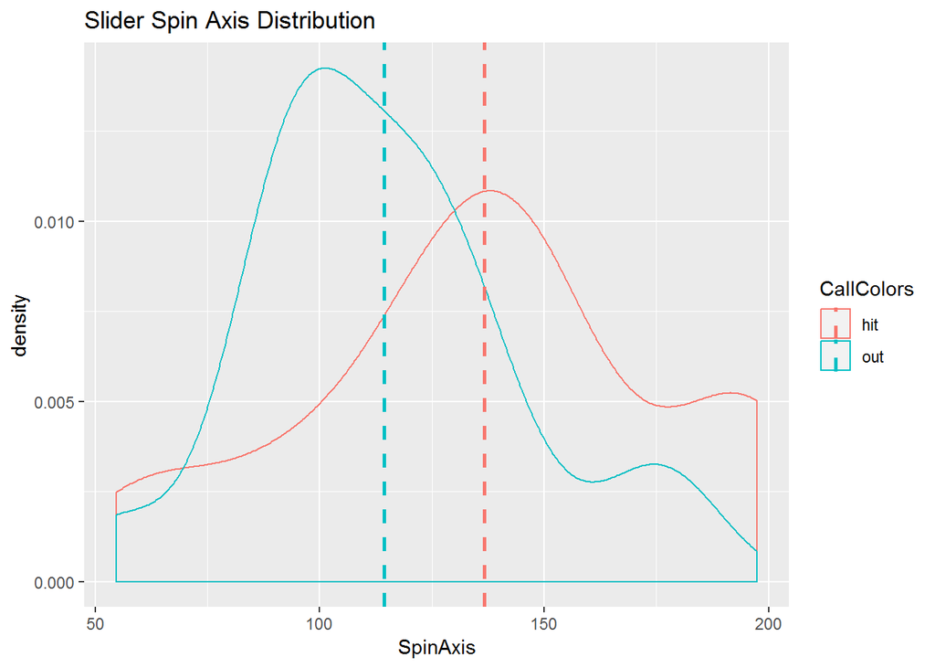

Strikes have a spin rate of around 150 degrees and balls have a spin rate of around 125 degrees. Spin axis distribution shows that sliders with tilt closer to 90 degrees are more likely to result in outs and sliders with tilt closer to 135 are more likely to be hit, but are also more likely to be strikes.

## Fastballs

### Location Densities

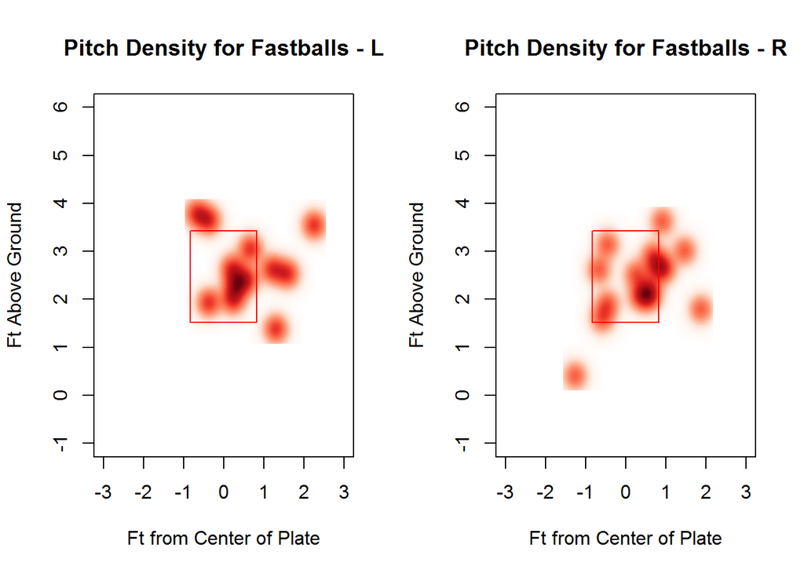

Pitch density for lefties shows that fastballs are scattered, with a hotspot belt high and a ball outside of the middle of the plate and a hotspot high and inside.

Pitch density for righties shows a hotspot ranging from mid-thigh to elbow on the inside edge of the plate.

### Velocity Distributions

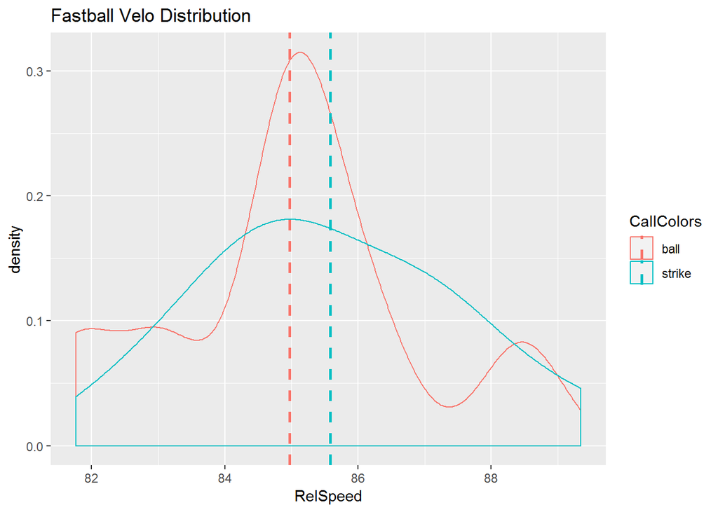

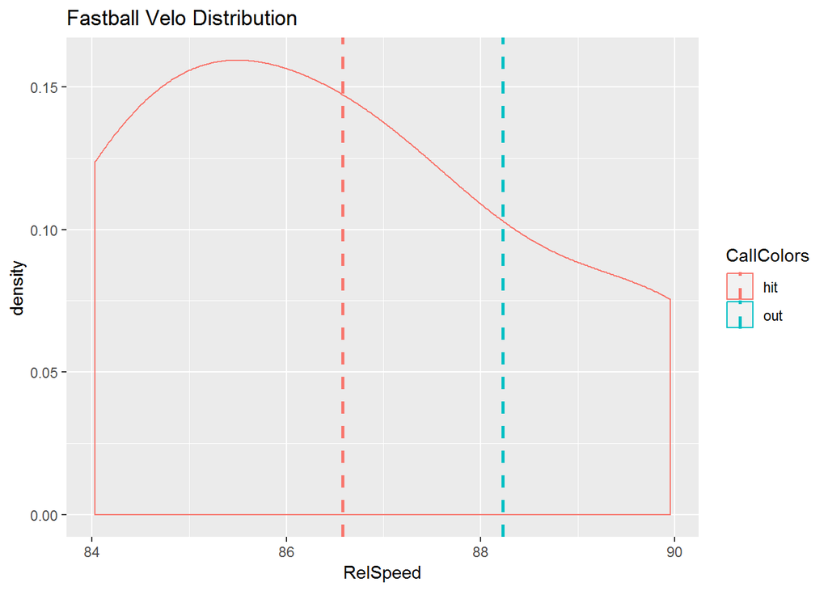

Release speed distributions show relative equality between balls and strikes, but a notable drop in balls occurring around 87 mph. The sample size for hit fastballs is small, but with current data slower fastballs are more likely to result in hits. It is likely that more data would show that the ideal velocity range to minimize balls and hits would be 86 to 88 mph.

### Release Height Distributions

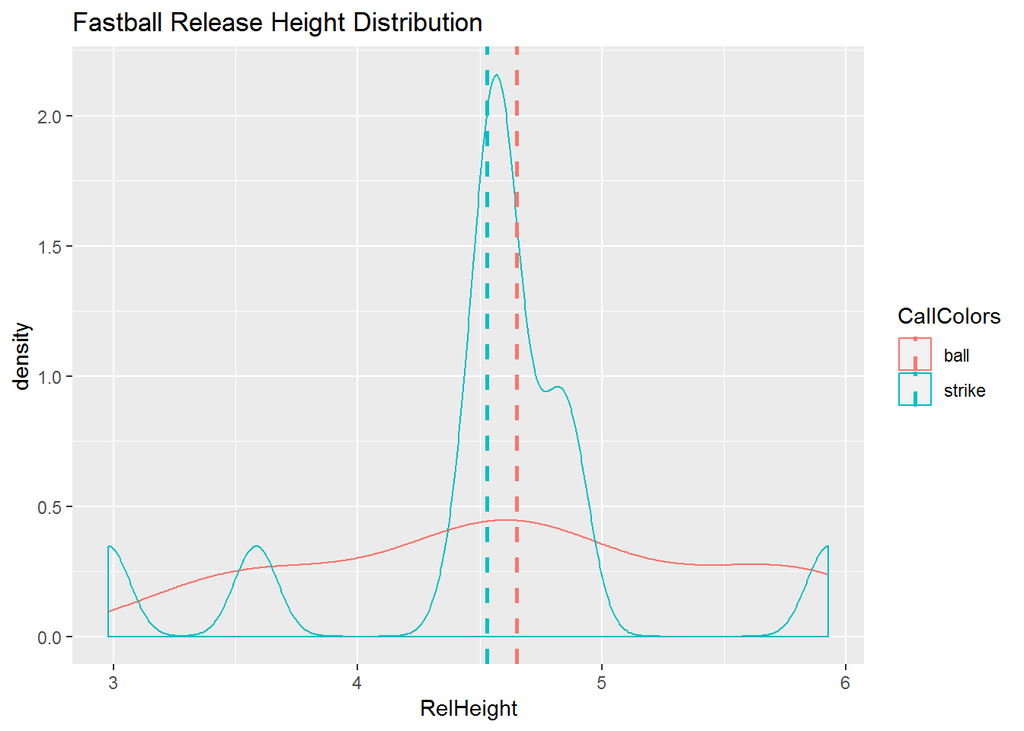

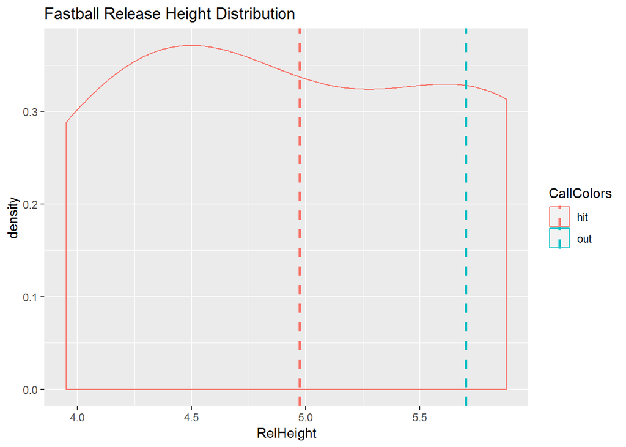

Release height disributions show that fastballs thrown from a release height of 4.5 are proportionally more likely to be strikes. Pitches thrown outside of the four clear recurring heights (3, 3.5, 4.5, 6) are balls. The sample size for hit fastballs is small, but with current data fastballs thrown closest to a height of 6 feet are more likely to be outs.

### Spin Axis Distributions

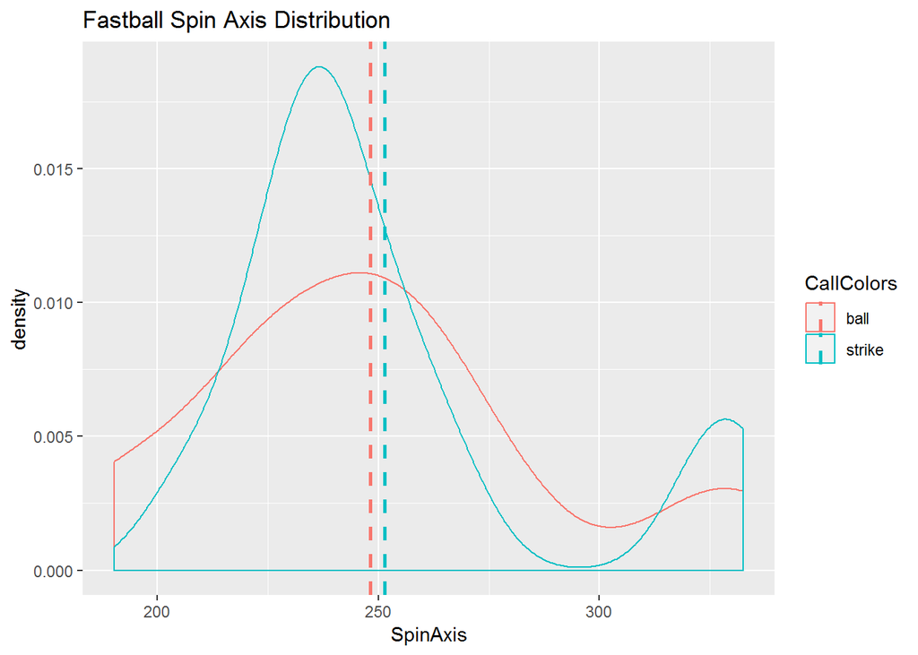

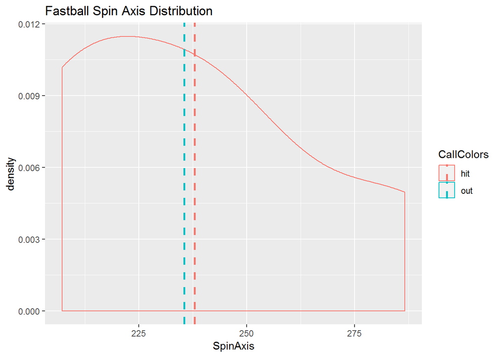

## Sinkers

### Location Densities

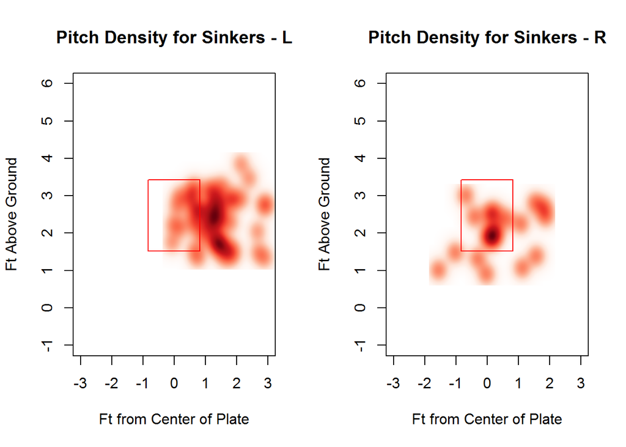

Pitch density for lefties shows that sinkers are being thrown outside, with a high density a ball and a half off of the plate, especially low.

Pitch density for righties shows that sinkers are scattered, with the most notable hotspot mid-thigh and middle of the plate.

### Velocity Distributions

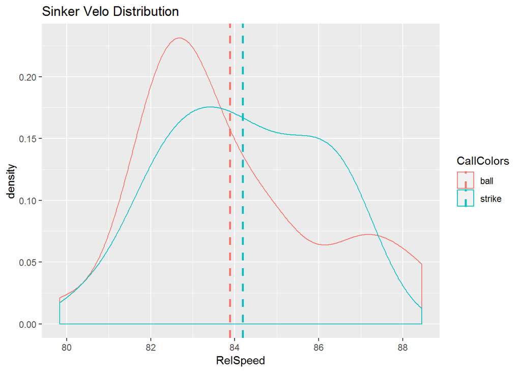

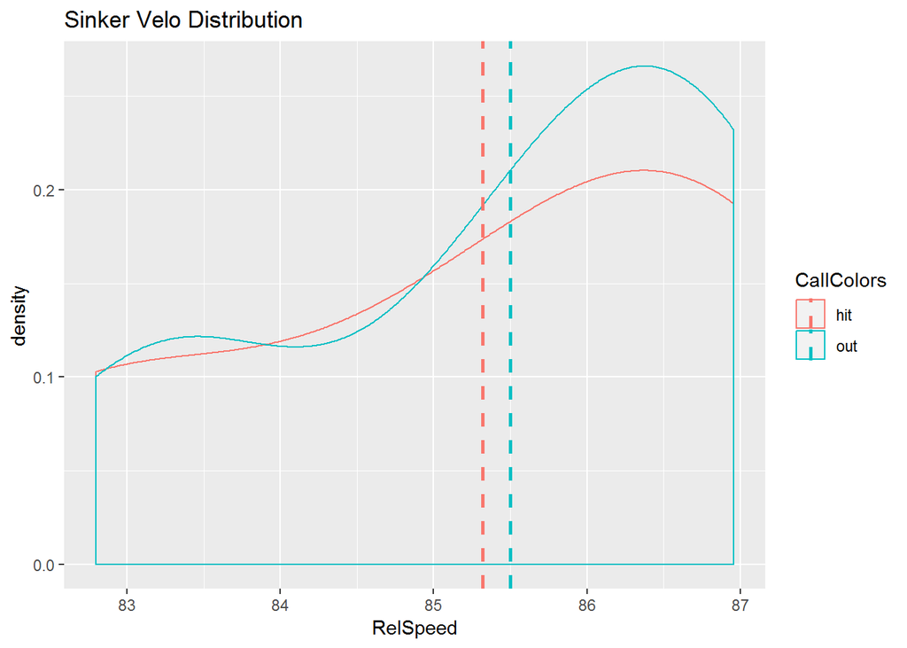

### Release Height Distributions

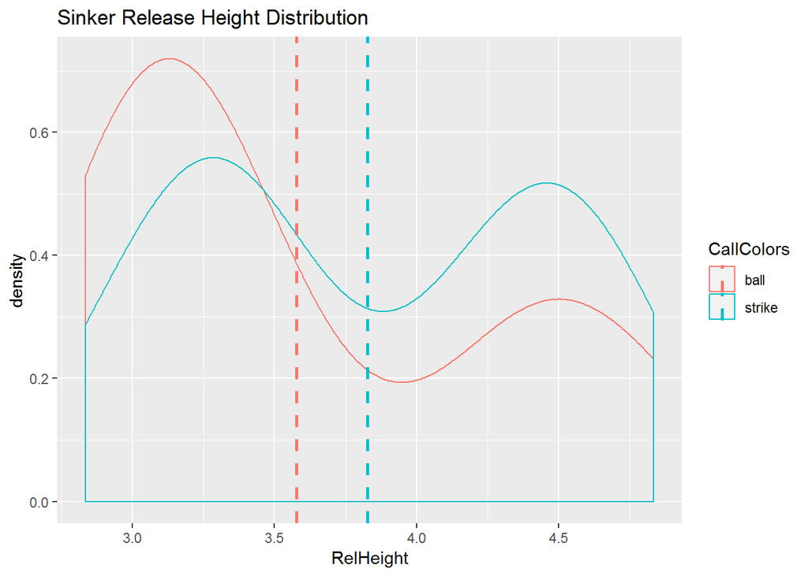

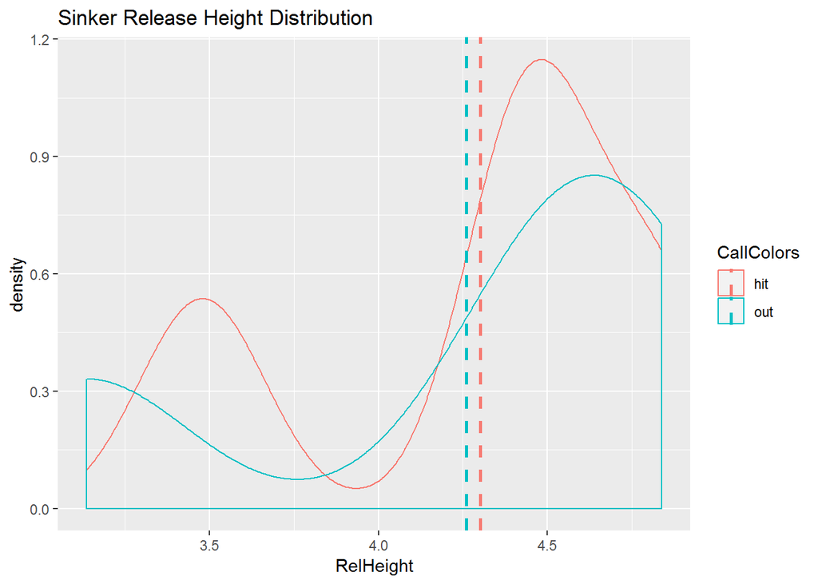

### Spin Axis Distributions

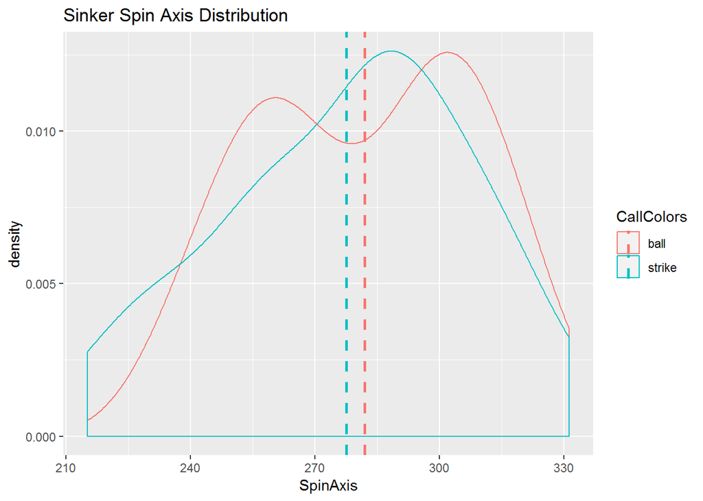

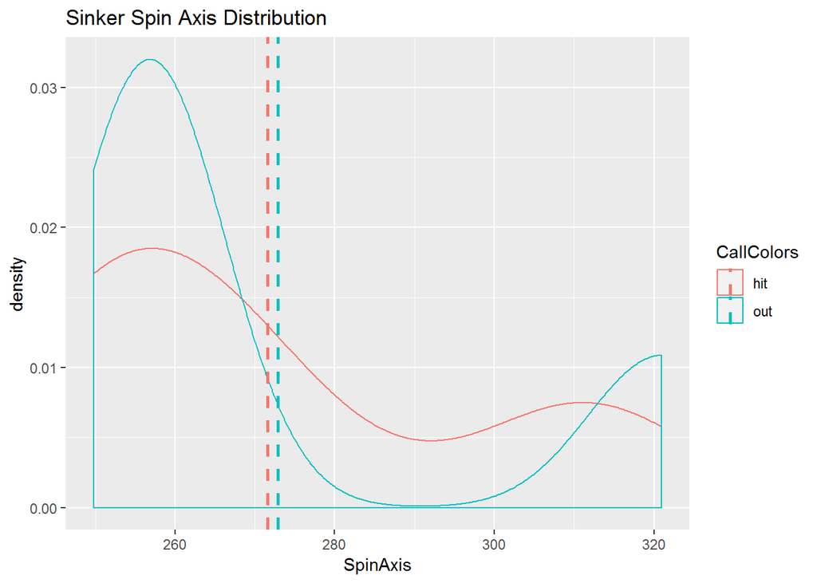

Spin axis densities show that sinkers thrown at 275 degrees or with a spin axis below 240 are more reliably strikes than balls. Sinkers with spin axes of 260 or 300 are more likely to be balls.

Sinkers with a spin axis between 215 and 240 are potentially useful as they are being thrown for strikes more than balls and are not being put in play.

## Curveballs

### Location Densities

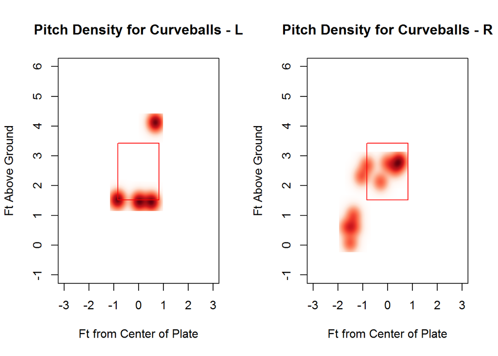

Pitch density for lefties shows that most curveballs to lefties have been thrown along the bottom edge of the plate.

Pitch density for righties shows that curveballs to righties have been concentrated outside below the knees and on the inside half of the plate at the elbow.

### Velocity Distributions

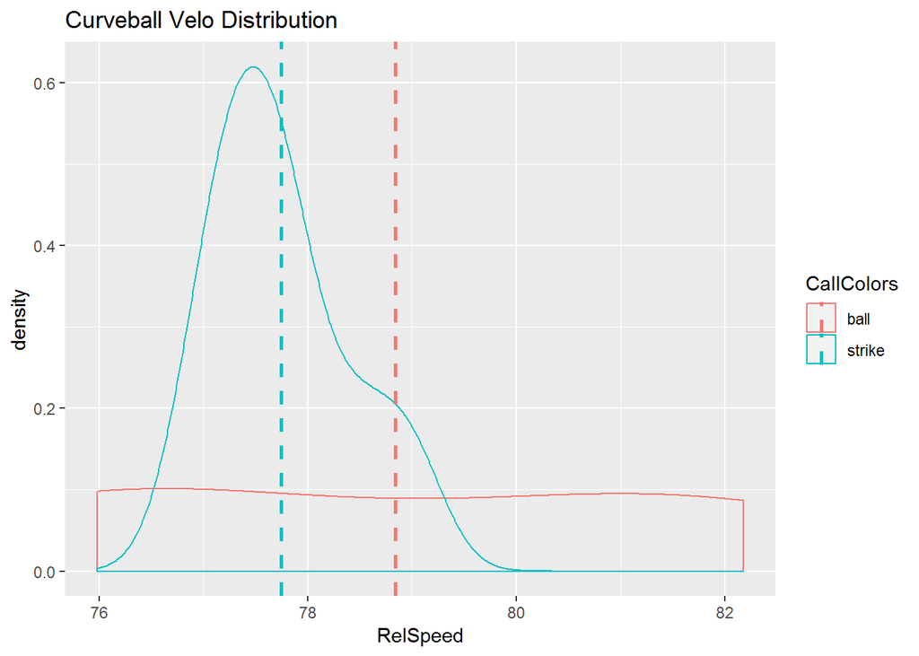

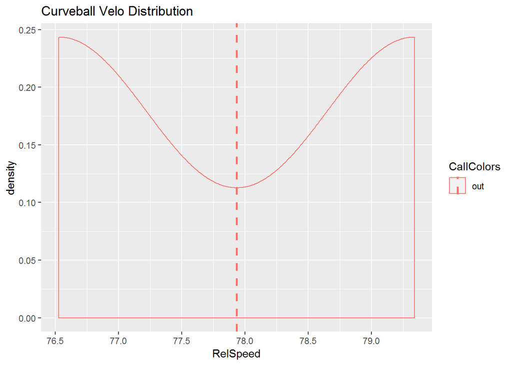

### Release Height Distributions

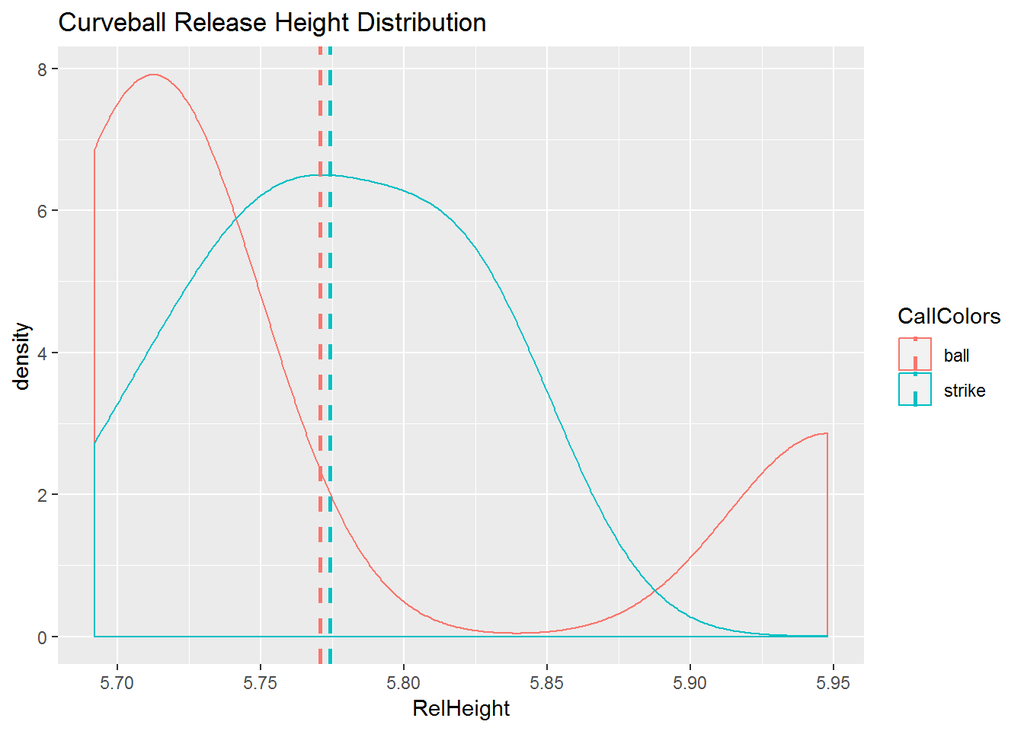

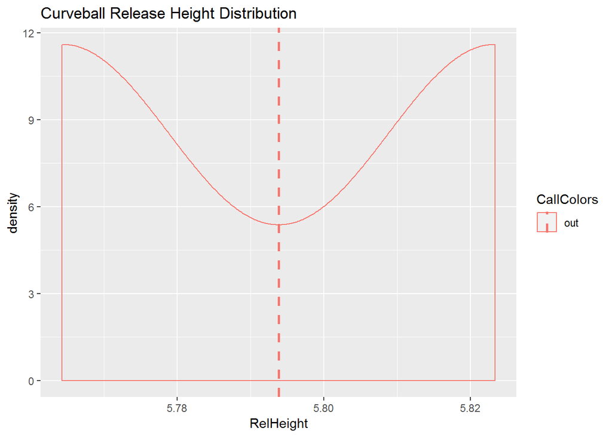

Release height densities show that most curveballs are thrown for strikes when thrown from a height of about 5.775. Curveballs thrown below 5.75 are more likely to result in balls and no curveball has resulted in a strike when thrown from a 5.95 release height. Outs have the highest probability of occurring when thrown from 5.82 or 5.76. This is an ideal range, as it also results most often in strikes.